# ESM 204 Homework 2

Grace Bianchi, Claire Meuter, Chase Tarr

4/19/2022

### 1. For each irrigation district, plot the marginal abatement cost data (from the data provided) and estimate a linear regression model with zero intercept. These estimated linear regressions will be your estimates of the marginal abatement cost curve (one for each irrigation district), which you will use for the remainder of this analysis.

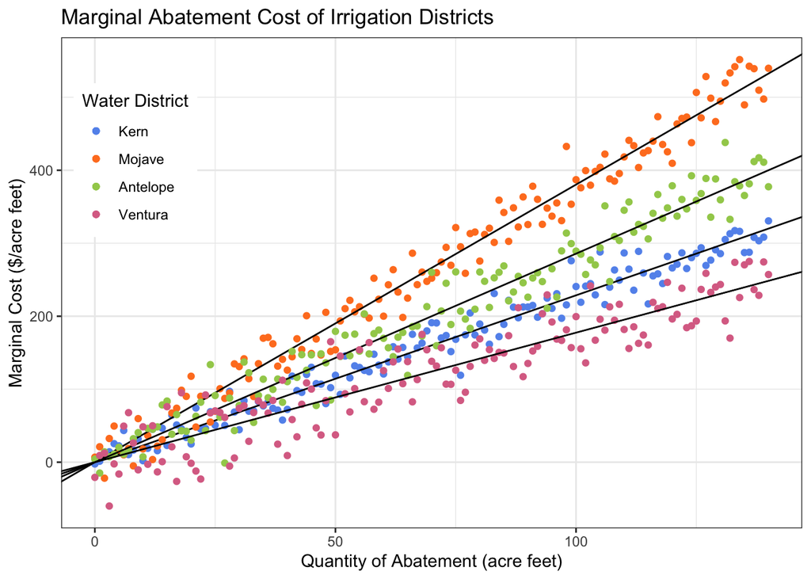

The estimated linear regression for each district with a zero intercept, where A is the reduction in water use in acre feet–

- Kern: Marginal Cost of abatement = 2.286A
- Mojave: Marginal Cost of Abatement = 3.804A
- Antelope: Marginal Cost of Abatement = 2.858A
- Ventura: Marginal Cost of Abatement = 1.776A

### 2. Using your estimated marginal abatement cost curves, derive each district’s demand curve for water. In other words, how much would each district be willing to pay for the right to use the first AF of water, second AF, etc.? Plot each district’s demand curve on a single graph. Which sector is willing to pay the most for the first AF of water?

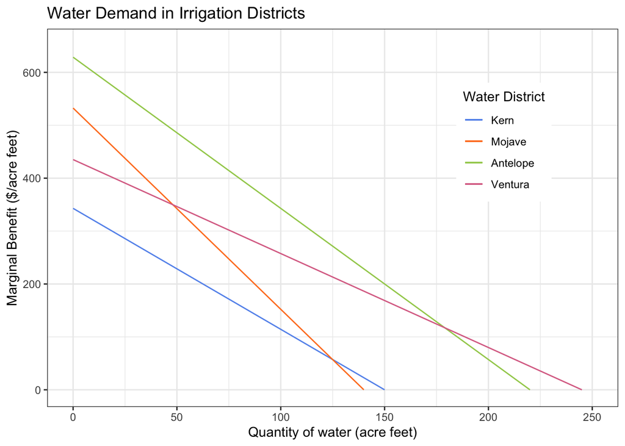

### 3. Here you will analyze three alternative policies for reducing water use among these irrigation districts. In total, these irrigation districts will need to reduce water consumption from the current 755 AF down to 500 AF. For each intervention listed below, perform the following calculations: (1) calculate the stringency of the policy (defined below for each intervention) required to achieve the 500 AF target, (2) calculate the total cost of meeting the target using that approach, (3) calculate the cost to each district, and (4) calculate the tax revenue generated.

#### **Cap without trade scenario**

1. In order to reduce the current consumption to 500 AF, each district must reduce their consumption by x:

   - 755-500 = 255

   - x = $\frac{255}{755}$ = 0.3377

#### Tax on water use

**Stringency:** The horizontal sum is calculated by solving for Q:

Kern MC = 2.286Q –> Kern Q = MC / 2.286

- Mojave Q = MC / 3.804
- Antelope Q = MC / 2.858
- Ventura Q = MC /1.776

The aggregate is Q= (1/2.286 + 1/3.804 + 1/2.858 + 1/1.776) * MC-> Q=1.613MC Using the abatement curve, we can plug in 255 for Q. 255 = 1.613 * MC –> MC = 158.063, therefore **the stringency or the magnitude of the tax is $158.03/AF.**

- Mojave: 158.063 = 3.804Q –> 41.552 AF, **cost to Mojave = $18,057.32**
- Antelope: 158.063 = 2.858Q –> 55.305 AF, **cost to Antelope = $30,181.80**
- Ventura: 158.063 = 1.776Q –> 88.999 AF, **cost to Ventura = $31,691.71**

The tax revenue is 500 * 158.063 **Tax revenue: $79,031.50**

#### Cap and trade

The stringency will be the same as the first scenario; each district must reduce their water use by a magnitude of the fraction $\frac{255}{755}$ = **0.3377**

The marginal cost of abatement is 158.063 using the last unit abated (255 AF) and the optimal quantity is equal to that found in the tax scenario. The district cost is the difference between that quanity and the quantity found in the cap no trade scenario. **The total cost is $38,742.98**

Kern: 158.063 = 2.286Q -> Q = 69.144 - 50.66 AF = selling 18.484 **Kern’s cost: (69.144 * 158.063 * 0.5) - (18.484 * 158.063) = $2542.92** Mojave: 158.063 = 3.804Q –> 41.552 AF - 47.28 AF = buying 5.728 **Mojave’s cost: (47.28 * 158.063) + (5.728 * 158.063) = $8,378.60** Antelope: 158.063 = 2.858Q –> 55.305 AF - 74.29 AF = buying 18.985 **Antelope’s cost: (74.29 * 158.063) + (18.985 * 158.063) = $14,743.33** Ventura: 158.063 = 1.776Q –> 88.999 AF - 82.74 AF = selling 6.259 **Ventura’s cost: (88.999 * 158.063) - (6.259 * 158.063) = $13,078.13**